# Check and update the PASA catalog first iteration results

Nicolas Delhomme

2015-02-25

# 1 Setup

Set the working dir

```r
setwd("/mnt/picea/projects/aspseq/asp201/rna/PASA/20150211")
```

Load libraries

```r
suppressPackageStartupMessages(library(genomeIntervals))
suppressPackageStartupMessages(library(IRanges))
```

source helper functions

```r
source("~/Git/UPSCb/src/R/pasaUtilities.R")
```

record the plotting params

```r
mar <- par("mar")
```

# 2 Analysis

## 2.1 Update the IDs

```r
gff3 <- "Potra01Catalog.gene_structures_post_PASA_updates.9924.gff3"
newgff3 <- sub("updates\\.[0-9]+","first-iteration-validated-updates",gff3)

df <- checkAndUpdatePasaGff3IDs(gff3 = gff3,
                                output = newgff3,
                                src="catalogV1")
```

```
## Initializing 1/7
## Considering gene split 2/7
## Considering gene merge 3/7
## Creating novel gene IDs 4/7
## Considering duplicate novel gene 5/7
## Considering novel gene 6/7
## Finalizing 7/7
```

## 2.2 Validate the novel gff

```r
message(sprintf("The validation was a %s",
                ifelse(validateProcessedGff3(newgff3),"success","failure")))
```

```
## The validation was a failure
```

We have a duplicated gene ID, the reason is that the original gene numbering breaks our assumption. And we have 4 duplicated gene <-> mRNA IDs; these occur for some novel genes - need to understand why. Now correcting them all.

```r
gff <- readGff3(newgff3)
```

We have the gene Potra001529g00030 coming after Potra001529g00040 although the coordinates indicate the opposite. And we have a novel gene with ID Potra001529g00040 instead of Potra001529g00042.

```r
dup <- which(getGffAttribute(gff[gff$type=="gene",],"ID")=="Potra001529g00040")
gff[gff$type=="gene",][(dup[1]-2):(dup[2]+2),]
```

```
## Object of class Genome_intervals_stranded
## 7 base intervals and 0 inter-base intervals(*):
## Potra001529 + [24, 11398)
## Potra001529 + [12577, 15536)
## Potra001529 + [25727, 26758)
## Potra001529 - [26780, 29107)
## Potra001529 - [29855, 32483)
## Potra001529 - [34180, 37295)
## Potra001529 - [41523, 44979)
##
## annotation:
##           seq_name strand inter_base    source type score phase
## 432040 Potra001529      +      FALSE catalogV1 gene    NA    NA
## 432113 Potra001529      +      FALSE catalogV1 gene    NA    NA
## 432125 Potra001529      +      FALSE catalogV1 gene    NA    NA
## 432134 Potra001529      -      FALSE catalogV1 gene    NA    NA
## 432142 Potra001529      -      FALSE catalogV1 gene    NA    NA
## 432150 Potra001529      -      FALSE catalogV1 gene    NA    NA
## 432174 Potra001529      -      FALSE catalogV1 gene    NA    NA
##                                                           gffAttributes
## 432040                      ID=Potra001529g00010;Name=Potra001529g00010
## 432113                      ID=Potra001529g00020;Name=Potra001529g00020
## 432125                      ID=Potra001529g00040;Name=Potra001529g00040
## 432134                      ID=Potra001529g00030;Name=Potra001529g00030
## 432142 ID=Potra001529g00040;Name=%2A%2A%20NO%20NAME%20ASSIGNED%20%2A%2A
## 432150 ID=Potra001529g00045;Name=%2A%2A%20NO%20NAME%20ASSIGNED%20%2A%2A
## 432174                      ID=Potra001529g00050;Name=Potra001529g00050
```

The first gene needs to be renamed Potra001529g00030, the second Potra001529g00040 and the third Potra001529g00042

## 2.3 The genes

### 2.3.1 Potra001529g00040 to Potra001529g00030

```r
gff$gffAttributes[
  which(gff$type=="gene")[dup[1]]:
  (which(gff$type=="gene")[dup[1]+1] -1)] <- gsub("Potra001529g00040",
                                                  "Potra001529g00030",
                                                  gff$gffAttributes[
                                                    which(gff$type=="gene")[dup[1]]:
                                                      (which(gff$type=="gene")[dup[1]+1] -1)])
```

### 2.3.2 Potra001529g00030 to Potra001529g00040

```r
gff$gffAttributes[
  (which(gff$type=="gene")[dup[1]+1]):
    (which(gff$type=="gene")[dup[1]+2] -1)] <- gsub("Potra001529g00030",
                                                    "Potra001529g00040",
                                                    gff$gffAttributes[
                                                      (which(gff$type=="gene")[dup[1]+1]):
                                                        (which(gff$type=="gene")[dup[1]+2] -1)])
```

### 2.3.3 Potra001529g00040 to Potra001529g00042

```r
gff$gffAttributes[
  which(gff$type=="gene")[dup[2]]:
    (which(gff$type=="gene")[dup[2]+1] -1)] <- gsub("Potra001529g00040",
                                                    "Potra001529g00042",
                                                    gff$gffAttributes[
                                                      which(gff$type=="gene")[dup[2]]:
                                                        (which(gff$type=="gene")[dup[2]+1] -1)])
```

## 2.4 The other cases

```r
mRNA.sel <- gff$type == "mRNA"
```

### 2.4.1 Potra000002g00095

```r
id <- "Potra000002g00095"
mRNA.pos <- which(getGffAttribute(gff[mRNA.sel,],"ID")==id)
start <- which(mRNA.sel)[mRNA.pos]
end <- which(mRNA.sel)[mRNA.pos+1]-2
gff[start,]$gffAttributes <- sub(paste(id,"",sep=";"),
                                paste(id,".1;",sep=""),
                                gff[start,]$gffAttributes)
gff[(start+1):end,]$gffAttributes <- paste(gff[(start+1):end,]$gffAttributes,"1",sep=".")
```

### 2.4.2 Potra000002g00125

```r
id <- "Potra000002g00125"
mRNA.pos <- which(getGffAttribute(gff[mRNA.sel,],"ID")==id)
start <- which(mRNA.sel)[mRNA.pos]
end <- which(mRNA.sel)[mRNA.pos+1]-2
gff[start,]$gffAttributes <- sub(paste(id,"",sep=";"),
                                paste(id,".1;",sep=""),
                                gff[start,]$gffAttributes)
gff[(start+1):end,]$gffAttributes <- paste(gff[(start+1):end,]$gffAttributes,"1",sep=".")
```

### 2.4.3 Potra000003g00035

```r
id <- "Potra000003g00035"
mRNA.pos <- which(getGffAttribute(gff[mRNA.sel,],"ID")==id)
start <- which(mRNA.sel)[mRNA.pos]
end <- which(mRNA.sel)[mRNA.pos+1]-2
gff[start,]$gffAttributes <- sub(paste(id,"",sep=";"),
                                paste(id,".1;",sep=""),
                                gff[start,]$gffAttributes)
gff[(start+1):end,]$gffAttributes <- paste(gff[(start+1):end,]$gffAttributes,"1",sep=".")
```

### 2.4.4 Potra000018g00020

```r
id <- "Potra000018g00020"
mRNA.pos <- which(getGffAttribute(gff[mRNA.sel,],"ID")==id)
start <- which(mRNA.sel)[mRNA.pos]
end <- which(mRNA.sel)[mRNA.pos+1]-2
gff[start,]$gffAttributes <- sub(paste(id,"",sep=";"),
                                paste(id,".1;",sep=""),
                                gff[start,]$gffAttributes)
gff[(start+1):end,]$gffAttributes <- sub(paste(id,"$",sep=""),
                                        paste(id,".1",sep=""),
                                        gff[(start+1):end,]$gffAttributes)
```

## 2.5 Update the gff

```r
writeGff3(gff,newgff3)
```

and revalidate

```r
message(sprintf("The validation was a %s",
                ifelse(validateProcessedGff3(newgff3),"success","failure")))
```

```
## The validation was a success
```

## 2.6 Report on the update

```r
table(df$status)
```

```
##
##    antisense    duplicate       merged merged.as.sv        novel
##            1           13          165            2         1259
##        split       stable
##            2        27472
```

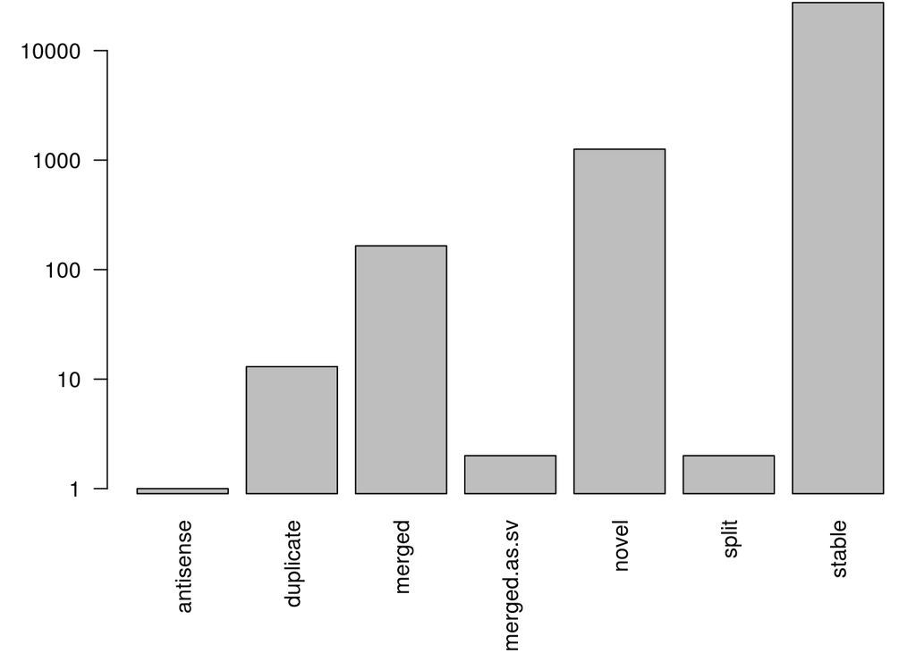

```r
par(mar=c(6.1,4.1,0.1,0.1))
barplot(table(df$status),log="y",las=2)
```

```r
par(mar=mar)
```

Save the gene IDs map as a csv

```r
write.csv(df,sub("\\.gff3","\\.csv",newgff3))
```

## 2.7 Report on PASA artifacts

### 2.7.1 overlapping genes

```r
gff <- readGff3(newgff3)
ovl <- findOverlaps(split(IRanges(start=gff[gff$type=="gene",1],
                                  end=gff[gff$type=="gene",2]),
                          seq_name(gff[gff$type=="gene",])),
                    ignoreSelf=TRUE,ignoreRedundant=TRUE)
```

There are a large number of overlapping genes some of them having many overlaps

```r
tab <- table(elementLengths(ovl))
sprintf("There are %s genes that overlap, independently of their strand",
        sum(tab[-1]))
```

```
## [1] "There are 874 genes that overlap, independently of their strand"
```

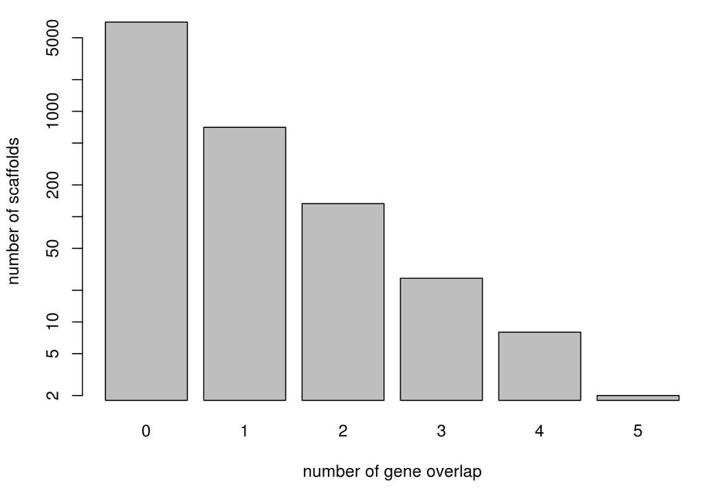

```r
par(mar=c(5.1,4.1,1.1,0.1))
barplot(tab,log="y",xlab="number of gene overlap",ylab="number of scaffolds")
```

```r
par(mar=mar)
```

Now check for the strand. Only a few are located on the same strand (~8%)

```r
table(gff[gff$type=="gene",][queryHits(ovl),]$strand ==
  gff[gff$type=="gene",][subjectHits(ovl),]$strand)
```

```
##
## FALSE  TRUE
##   999    92
```